# Question

A 3D shape’s base is the 2D region enclosed by $y=0$ and $y=f(x)=x^{1.1}-x^{5.2}$ on the $xy$ plane. For every plane perpendicular to the $x$ axis, with $0<x<1$, there is a square cross section.

I have attempted to draw this below.

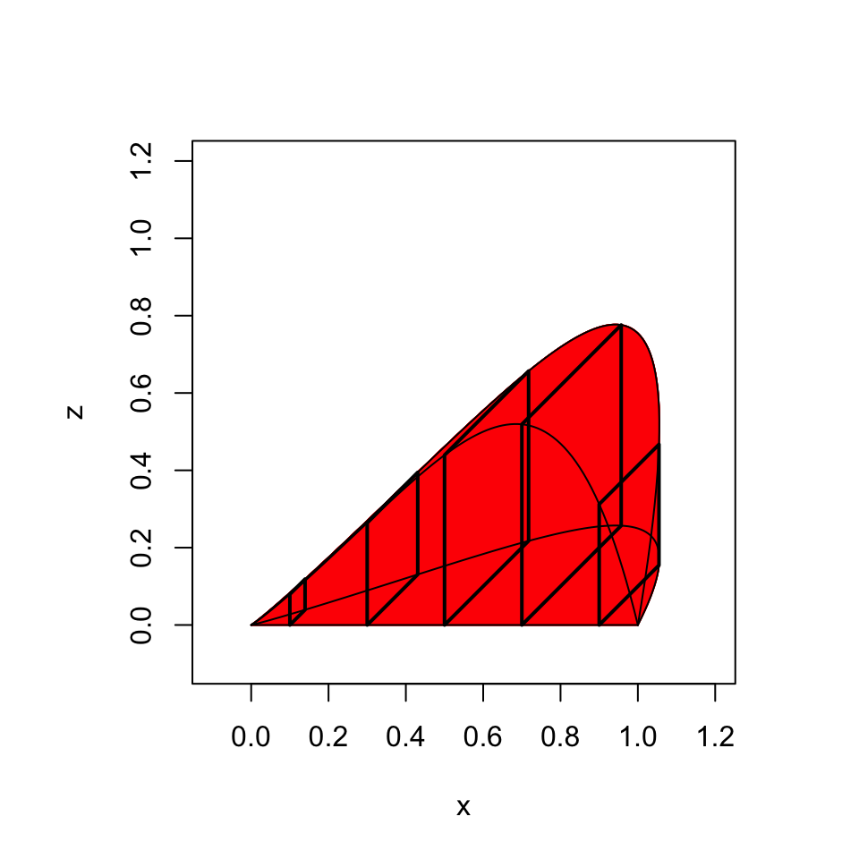

And here is a spinning animation. Does that help?

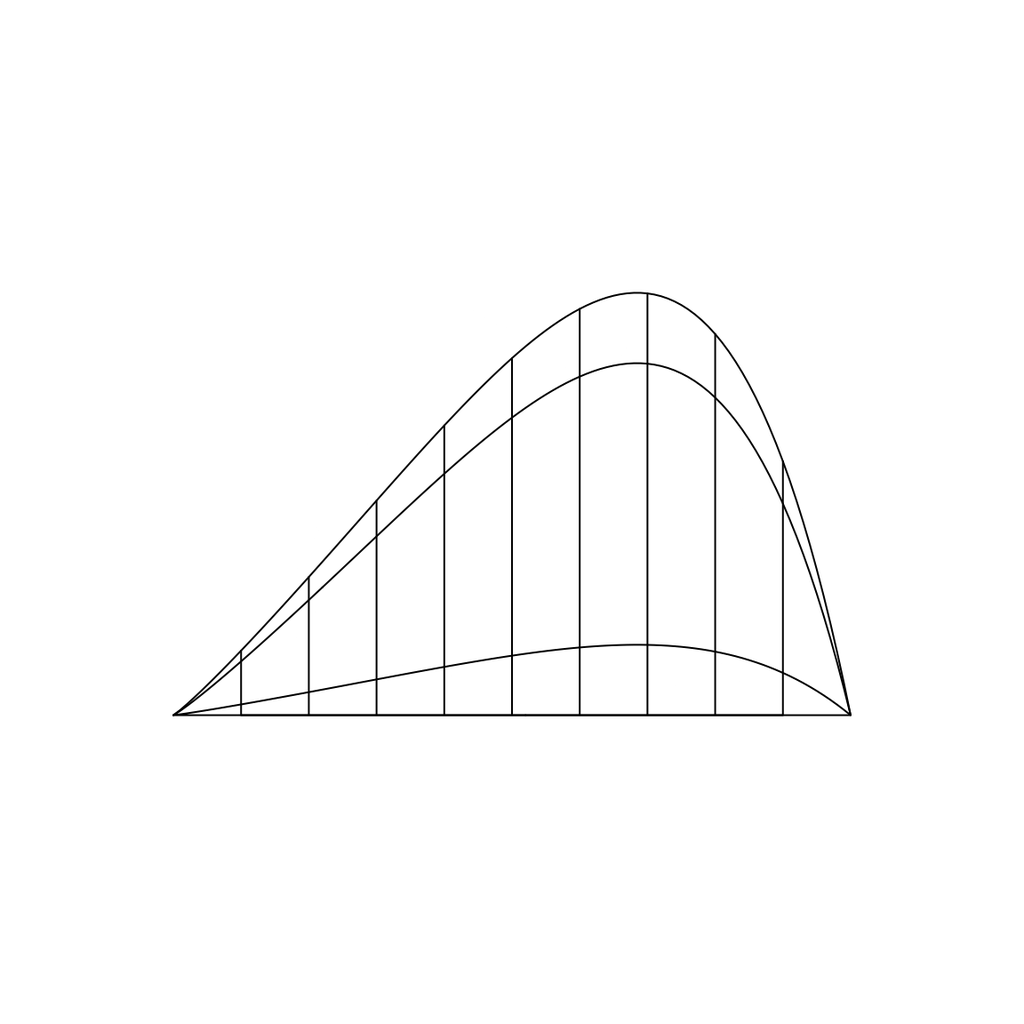

Find the volume of the shape; the tolerance is $\pm 0.001$ cubic units. You might find [this video](https://www.khanacademy.org/math/ap-calculus-ab/ab-applications-of-integration-new/ab-8-7/v/volume-with-cross-sections-intro) helpful. The general topic is “[volume from cross sections](https://en.wikibooks.org/wiki/Calculus/Volume)”; you might try a variety of resources by searching this phrase in your favorite search engine.

# Solution

The volume can be found by accumulating the volumes of many “slabs”, where each slab is a square with some infinitesimal thickness.

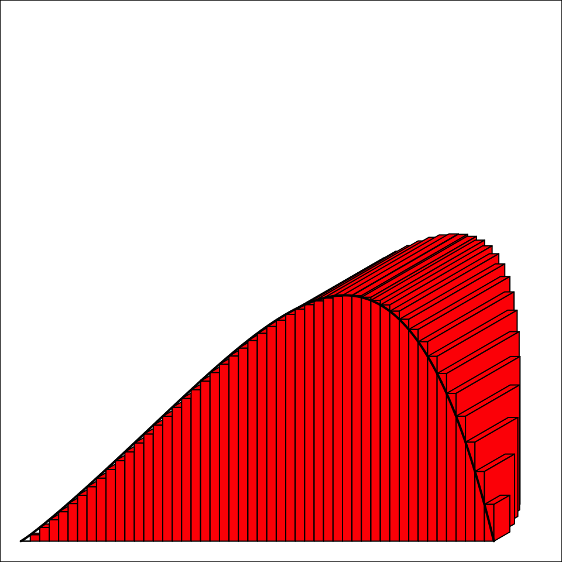

The volume of each slab depends on $x$. The width and height are each $f(x)$ and the thickness is an [infinitesimal](https://en.wikipedia.org/wiki/Infinitesimal) $dx$.

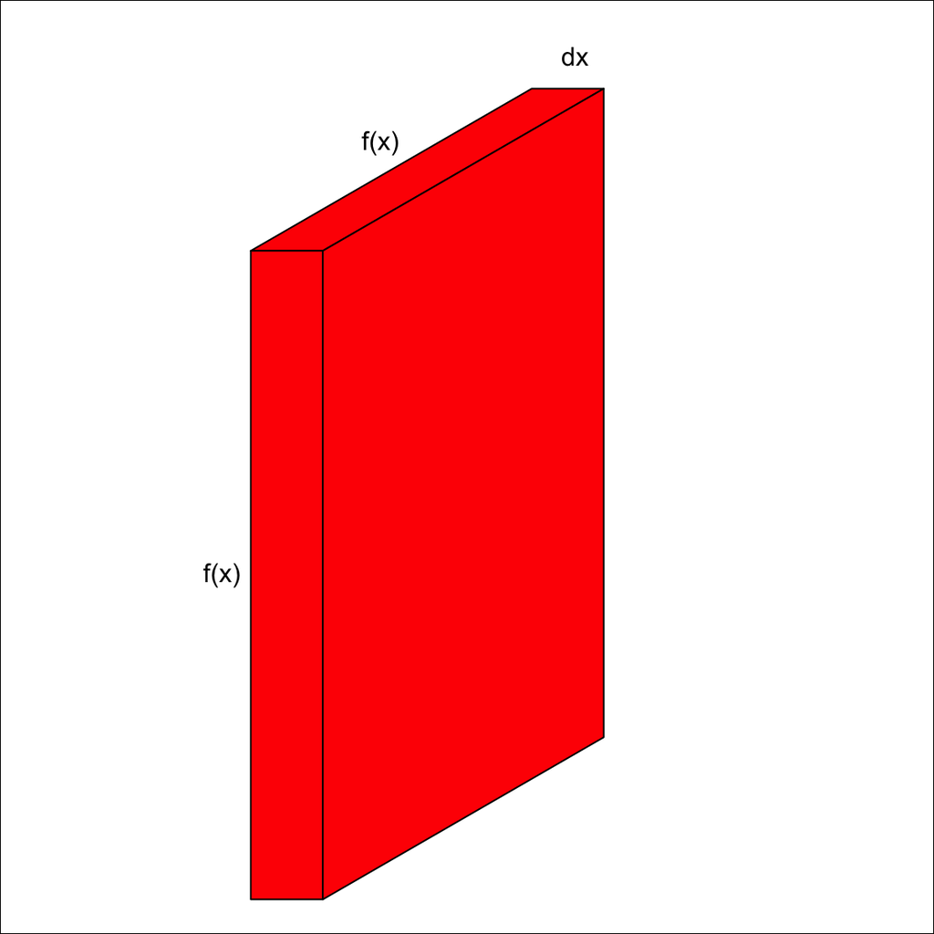

So, we can find the infinitesimal volume as a function of $x$.

$$dV = (f(x))^2 \,dx$$

$$dV = (x^{1.1}-x^{5.2})^2
\,dx$$

We need to sum up all the differential volumes from $x=0$ to $x=1$.

$$V = \int_{x=0}^{x=1} dV$$

$$V = \int_{0}^{1} (x^{1.1}-x^{5.2})^2
\,dx$$

You can apply the [binomial theorem](https://en.wikipedia.org/wiki/Binomial_theorem).

$$V = \int_{0}^{1}
(x^{2.2}-2x^{6.3}+x^{10.4}) \,dx$$

Let $g(x)$ be an antiderivative of $(f(x))^2$ such that $g(0)=0$.

$$g(x)~=~\frac{1}{3.2}x^{3.2}-\frac{2}{7.3}x^{7.3}+\frac{1}{11.4}x^{11.4}$$

We use the antiderivative to find the definite integral.

$$V = g(1)-g(0)$$

$$V =
\left(\frac{1}{3.2}(1)^{3.2}-\frac{2}{7.3}(1)^{7.3}+\frac{1}{11.4}(1)^{11.4}\right)
-
\left(\frac{1}{3.2}(0)^{3.2}-\frac{2}{7.3}(0)^{7.3}+\frac{1}{11.4}(0)^{11.4}\right)$$

$$V =
\left(\frac{1}{3.2}-\frac{2}{7.3}+\frac{1}{11.4}\right) -
\left(0-0+0\right)$$

$$V ~=~
\frac{1}{3.2}-\frac{2}{7.3}+\frac{1}{11.4}$$
$$V \approx 0.1262467$$

# Meta-information

extype: num exsolution: 0.1262467 exname: volume_by_slabs extol: 0.001